# CHICAGO CRIMES ANALYSIS

Predicting crimes in Chicago and creating an alert system.

We’re using the Chicago Crime Dataset from 2012-2017 for this analysis. We’re predicting crime using FB Prophet. There is also an crime alert system that would alert nearby crimes based on given user Location.

### For my other articles, visit my [BLOG](https://samirak93.github.io/analytics/)

#### Contact me on [Twitter](http://twitter.com/Samirak93) or [LinkedIn](http://linkedin.com/in/samirakumar/)

```python
%load_ext watermark
```

```python
%watermark -v -u -n -t -z -a 'Samira Kumar' -p numpy,scipy,matplotlib,sklearn,fbprophet,bokeh,geopy
```

```
Samira Kumar
last updated: Thu Dec 13 2018 22:55:34 PST

CPython 2.7.15
IPython 5.8.0

numpy 1.15.3
scipy 1.1.0
matplotlib 2.2.3
sklearn 0.19.2
fbprophet 0.3
bokeh 1.0.2
geopy 1.17.0
```

### **INDEX:**

1: CRIME ALERT SYSTEM  
2: FB PROPHET TO PREDICT CRIMES IN CHICAGO

### CRIME ALERT SYSTEM

```python
import pandas as pd
import numpy as np
import matplotlib.pyplot as plt

df=pd.DataFrame(pd.read_csv('cleaned_file.csv'))
df.head()
```

|  | Unnamed: 0 | ID | Case Number | Date | Block | IUCR | Primary Type | Description | Location Description | Arrest | ... | Updated On | Latitude | Longitude | Location | time_crime | time_hour | minutes | seconds | dates | day_of_week |
| --- | --- | --- | --- | --- | --- | --- | --- | --- | --- | --- | --- | --- | --- | --- | --- | --- | --- | --- | --- | --- | --- |
| 0 | 3 | 10508693 | HZ250496 | 2016-05-03 23:40:00 | 013XX S SAWYER AVE | 0486 | BATTERY | DOMESTIC BATTERY SIMPLE | APARTMENT | True | ... | 05/10/2016 03:56:50 PM | 41.864073 | -87.706819 | (41.864073157, -87.706818608) | 0 days 11:40:00.000000000 | 23 | 40 | 0 | 2016-05-03 | 1 |
| 1 | 89 | 10508695 | HZ250409 | 2016-05-03 21:40:00 | 061XX S DREXEL AVE | 0486 | BATTERY | DOMESTIC BATTERY SIMPLE | RESIDENCE | False | ... | 05/10/2016 03:56:50 PM | 41.782922 | -87.604363 | (41.782921527, -87.60436317) | 0 days 09:40:00.000000000 | 21 | 40 | 0 | 2016-05-03 | 1 |
| 2 | 197 | 10508697 | HZ250503 | 2016-05-03 23:31:00 | 053XX W CHICAGO AVE | 0470 | PUBLIC PEACE VIOLATION | RECKLESS CONDUCT | STREET | False | ... | 05/10/2016 03:56:50 PM | 41.894908 | -87.758372 | (41.894908283, -87.758371958) | 0 days 11:31:00.000000000 | 23 | 31 | 0 | 2016-05-03 | 1 |
| 3 | 673 | 10508698 | HZ250424 | 2016-05-03 22:10:00 | 049XX W FULTON ST | 0460 | BATTERY | SIMPLE | SIDEWALK | False | ... | 05/10/2016 03:56:50 PM | 41.885687 | -87.749516 | (41.885686845, -87.749515983) | 0 days 10:10:00.000000000 | 22 | 10 | 0 | 2016-05-03 | 1 |
| 4 | 911 | 10508699 | HZ250455 | 2016-05-03 22:00:00 | 003XX N LOTUS AVE | 0820 | THEFT | $500 AND UNDER | RESIDENCE | False | ... | 05/10/2016 03:56:50 PM | 41.886297 | -87.761751 | (41.886297242, -87.761750709) | 0 days 10:00:00.000000000 | 22 | 0 | 0 | 2016-05-03 | 1 |

5 rows × 29 columns

### Creating the cluster

In order to create a crime alert, we're clustering a sample of 500000 crimes into 200 clusters. The cluster size can be any number. Higher the cluster number, better the alert system.

```python
from sklearn.cluster import KMeans
from sklearn import metrics
from sklearn.metrics import pairwise_distances
data=df.sample(500000).copy()
ml = KMeans(n_clusters=200, init='k-means++')
ml.fit(data[['Longitude', 'Latitude']])
```

```
KMeans(algorithm='auto', copy_x=True, init='k-means++', max_iter=300,
    n_clusters=200, n_init=10, n_jobs=1, precompute_distances='auto',
    random_state=None, tol=0.0001, verbose=0)
```

```python
cluster = ml.cluster_centers_
cluster[:10]
```

```
array([[-87.58564446,  41.76842148],
       [-87.70954061,  41.88284319],
       [-87.66222958,  41.76711367],
       [-87.66692053,  41.9410608 ],
       [-87.78625868,  41.93248014],
       [-87.62523552,  41.85573192],
       [-87.62398212,  41.72210565],
       [-87.72503318,  41.80416549],
       [-87.76813019,  41.8947028 ],
       [-87.68737204,  42.01373099]])
```

#### Total crimes for each cluster

```python
X = data[['Longitude','Latitude']].values
predictions = ml.fit_predict(X)
kclustered = pd.concat([data.reset_index(),
                       pd.DataFrame({'Cluster':predictions})],
                      axis=1)
kclustered.drop('index', axis=1, inplace=True)
centers = ml.cluster_centers_
kcenters=pd.DataFrame(centers)
kcenters=kcenters.rename(columns={0:'Longitude',1:'Latitude'})
kcenters['Total Crimes']=kclustered.groupby('Cluster')['ID'].count().reset_index()['ID']
kcenters
```

|  | Longitude | Latitude | Total Crimes |
| --- | --- | --- | --- |
| 0 | -87.562543 | 41.757362 | 5633 |
| 1 | -87.723997 | 41.874345 | 3391 |
| 2 | -87.647856 | 41.737336 | 3153 |
| 3 | -87.626566 | 41.898832 | 5280 |
| 4 | -87.661300 | 41.989576 | 2874 |
| 5 | -87.689190 | 41.788970 | 2284 |
| 6 | -87.787579 | 41.936611 | 1495 |
| 7 | -87.604033 | 41.814649 | 3050 |
| 8 | -87.719462 | 41.922614 | 2309 |
| 9 | -87.644212 | 41.691239 | 1845 |
| 10 | -87.660230 | 41.866823 | 1954 |
| 11 | -87.613065 | 41.771176 | 2440 |
| 12 | -87.767568 | 41.778903 | 971 |
| 13 | -87.901201 | 41.976360 | 2377 |
| 14 | -87.651969 | 41.946508 | 5646 |
| 15 | -87.671957 | 41.764680 | 1935 |
| 16 | -87.768894 | 41.896212 | 2872 |
| 17 | -87.705489 | 41.966385 | 1889 |
| 18 | -87.536134 | 41.688851 | 581 |
| 19 | -87.663652 | 41.781110 | 3070 |
| 20 | -87.697404 | 41.849916 | 2782 |
| 21 | -87.772455 | 41.976608 | 1316 |
| 22 | -87.626050 | 41.736157 | 1810 |
| 23 | -87.638456 | 41.812819 | 1794 |
| 24 | -87.619734 | 41.705476 | 2568 |
| 25 | -87.626894 | 41.849017 | 3692 |
| 26 | -87.760932 | 41.924089 | 2801 |
| 27 | -87.668072 | 41.925246 | 1987 |
| 28 | -87.571464 | 41.723318 | 1974 |
| 29 | -87.697984 | 41.742965 | 1241 |
| ... | ... | ... | ... |
| 170 | -87.792075 | 41.980644 | 901 |
| 171 | -87.759794 | 41.968912 | 1760 |
| 172 | -87.604044 | 41.704924 | 1596 |
| 173 | -87.709427 | 41.843848 | 2593 |
| 174 | -87.779456 | 41.924424 | 2054 |
| 175 | -87.608273 | 41.760469 | 2724 |
| 176 | -87.683026 | 41.870676 | 1741 |
| 177 | -87.639767 | 41.866448 | 1681 |
| 178 | -87.631570 | 41.793930 | 1741 |
| 179 | -87.669610 | 41.809749 | 2468 |
| 180 | -87.644542 | 41.936753 | 3003 |
| 181 | -87.698248 | 41.868886 | 3148 |
| 182 | -87.729729 | 41.913196 | 2945 |
| 183 | -87.735547 | 41.879182 | 4266 |
| 184 | -87.763710 | 41.795112 | 922 |
| 185 | -87.651172 | 41.706862 | 2078 |
| 186 | -87.629293 | 41.888985 | 5121 |
| 187 | -87.780305 | 41.996226 | 696 |
| 188 | -87.658627 | 41.684744 | 2071 |
| 189 | -87.684192 | 41.996241 | 2208 |
| 190 | -87.612480 | 41.748742 | 2111 |
| 191 | -87.679131 | 41.911361 | 3091 |
| 192 | -87.706255 | 41.757211 | 1331 |
| 193 | -87.603158 | 41.779609 | 3281 |
| 194 | -87.648339 | 41.766753 | 3625 |
| 195 | -87.686446 | 42.013764 | 2195 |
| 196 | -87.811133 | 41.980889 | 739 |
| 197 | -87.727662 | 41.853131 | 2391 |
| 198 | -87.622806 | 41.676020 | 2847 |
| 199 | -87.649648 | 41.891030 | 1628 |

200 rows × 3 columns

#### Using geocoders, we find the address for each cluster centers. This is just for plotting the cluster centers on Folium

```python
from geopy.geocoders import Nominatim
geolocator=Nominatim(timeout=3)

address=[]
for index,row in kcenters.iterrows():
    rev_location=geolocator.reverse(np.array([row.Latitude, row.Longitude]))
    address.append(rev_location.address)
kcenters['Address']=address
kcenters.head()
```

|  | Longitude | Latitude | Total Crimes | Address |
| --- | --- | --- | --- | --- |
| 0 | -87.562543 | 41.757362 | 5633 | 2532-2546, East 76th Street, South Shore HIsto... |
| 1 | -87.723997 | 41.874345 | 3391 | 3922, West Congress Parkway, West Garfield Par... |
| 2 | -87.647856 | 41.737336 | 3153 | 8614, South Sangamon Street, Chester Highlands... |
| 3 | -87.626566 | 41.898832 | 5280 | America-Fore Building, 844, North Rush Street,... |
| 4 | -87.661300 | 41.989576 | 2874 | 5917, North Magnolia Avenue, Edgewater Glen, E... |

### Plotting the cluster centers on Folium

```python
import folium

m = folium.Map(location=[41.8781,-87.64], zoom_start=11)

for i in range(0,len(kcenters)):
   folium.Circle(
      location=[kcenters.iloc[i]['Latitude'], kcenters.iloc[i]['Longitude']],
       popup = (
        "<b>Location:</b> {loc}</br></br>"
        "<b>Crimes: </b> {crime}<br>"
    ).format(loc=str(kcenters.iloc[i]['Address']), crime=str(kcenters.iloc[i]['Total Crimes'])),
      radius=kcenters.iloc[i]['Total Crimes']/15,
      color='red',
      fill=True,
      fill_color='red',
      fill_opacity=0.5
   ).add_to(m)
folium.TileLayer('cartodbpositron').add_to(m)
m.save('clustered_200.html')
m
```

[interactive chart not shown]

```python
data['cluster'] = ml.predict(data[['Longitude','Latitude']])
data[['ID','Latitude','Longitude','Block','cluster']].sample(10)
```

|  | ID | Latitude | Longitude | Block | cluster |
| --- | --- | --- | --- | --- | --- |
| 1059816 | 10130901 | 41.916053 | -87.719181 | 019XX N LAWNDALE AVE | 8 |
| 1181829 | 10343488 | 41.883165 | -87.769861 | 001XX N MENARD AVE | 56 |
| 790069 | 9587080 | 41.754593 | -87.741529 | 076XX S CICERO AVE | 49 |
| 432678 | 8993045 | 41.747393 | -87.585439 | 081XX S STONY ISLAND AVE | 41 |
| 1241362 | 10446682 | 41.894166 | -87.621850 | 002XX E ERIE ST | 101 |
| 1336621 | 10634007 | 41.839811 | -87.617142 | 030XX S DR MARTIN LUTHER KING JR DR | 62 |
| 585300 | 9238321 | 41.961703 | -87.698484 | 044XX N CALIFORNIA AVE | 17 |
| 571046 | 9215466 | 41.750802 | -87.599109 | 079XX S DOBSON AVE | 72 |
| 754525 | 9522175 | 41.912324 | -87.749758 | 049XX W ST PAUL AVE | 147 |
| 1321870 | 10609016 | 41.744094 | -87.594707 | 012XX E 83RD ST | 72 |

### We're predicting the same data to find cluster of each crime. We can plot the cluster and centers in a voronoi plot as below

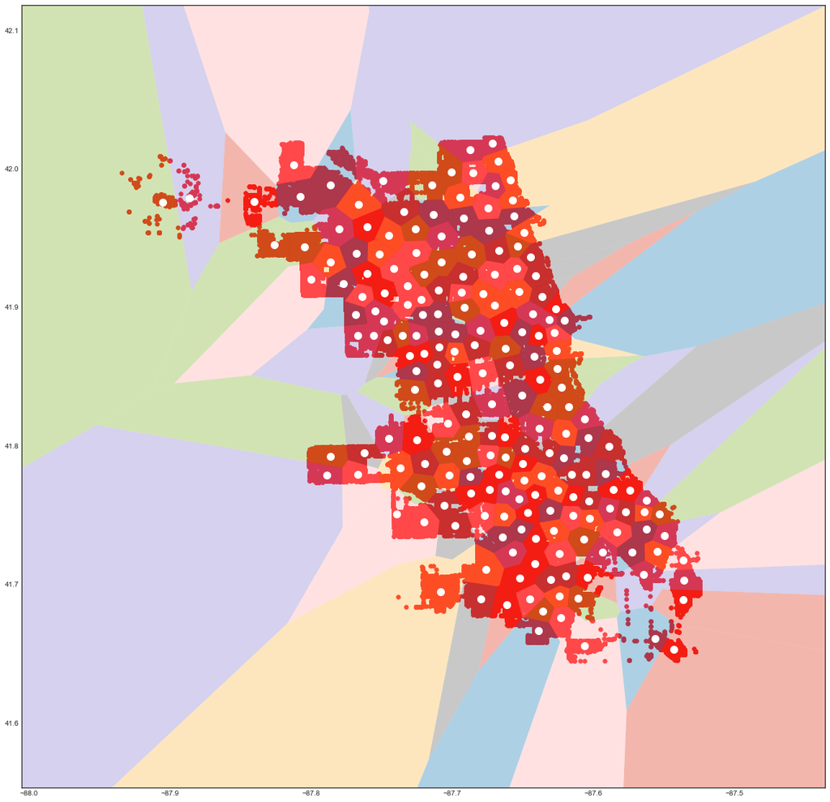

```python
from scipy.spatial import Voronoi

def voronoi_polygons_2d(vor, radius=None):
    """
    Reconstruct infinite voronoi regions in a 2D diagram to finite
    regions.

    Input_args:
    vor : Voronoi
        Input diagram
    radius : float, optional
        Distance to 'points at infinity'.

    :returns:
    regions : list of tuples
        Indices of vertices in each revised Voronoi regions.
    vertices : list of tuples
        Coordinates for revised Voronoi vertices. Same as coordinates
        of input vertices, with 'points at infinity' appended to the
        end.

    """
    if vor.points.shape[1] != 2:
        raise ValueError("Requires 2D input")

    new_regions = []
    new_vertices = vor.vertices.tolist()

    center = vor.points.mean(axis=0)
    if radius is None:
        radius = vor.points.ptp().max()*2

    # Construct a map containing all ridges for a given point
    all_ridges = {}
    for (p1, p2), (v1, v2) in zip(vor.ridge_points, vor.ridge_vertices):
        all_ridges.setdefault(p1, []).append((p2, v1, v2))
        all_ridges.setdefault(p2, []).append((p1, v1, v2))

    # Reconstruct infinite regions
    for p1, region in enumerate(vor.point_region):
        vertices = vor.regions[region]

        if all([v >= 0 for v in vertices]):
            # finite region
            new_regions.append(vertices)
            continue

        # reconstruct a non-finite region
        ridges = all_ridges[p1]
        new_region = [v for v in vertices if v >= 0]

        for p2, v1, v2 in ridges:
            if v2 < 0:
                v1, v2 = v2, v1
            if v1 >= 0:
                # finite ridge: already in the region
                continue

            # Compute the missing endpoint of an infinite ridge

            t = vor.points[p2] - vor.points[p1] # tangent
            t /= np.linalg.norm(t)
            n = np.array([-t[1], t[0]])  # normal

            midpoint = vor.points[[p1, p2]].mean(axis=0)
            direction = np.sign(np.dot(midpoint - center, n)) * n
            far_point = vor.vertices[v2] + direction * radius

            new_region.append(len(new_vertices))
            new_vertices.append(far_point.tolist())

        # sort region counterclockwise
        vs = np.asarray([new_vertices[v] for v in new_region])
        c = vs.mean(axis=0)
        angles = np.arctan2(vs[:,1] - c[1], vs[:,0] - c[0])
        new_region = np.array(new_region)[np.argsort(angles)]

        # finish
        new_regions.append(new_region.tolist())

    return new_regions, np.asarray(new_vertices)

# make up data points
points = cluster

# compute Voronoi tesselation
vor = Voronoi(points)

# compute regions
regions, vertices = voronoi_polygons_2d(vor)

# prepare figure
plt.style.use('seaborn-white')
fig = plt.figure()
fig.set_size_inches(20,20)

#geomap
# centroids
plt.plot(points[:,0], points[:,1], 'wo',markersize=10)

# colorize
for region in regions:
    polygon = vertices[region]
    plt.fill(*zip(*polygon), alpha=0.4)

plt.scatter(data['Longitude'],data['Latitude'],c='red')
plt.xlim(vor.min_bound[0] - 0.1, vor.max_bound[0] + 0.1)
plt.ylim(vor.min_bound[1] - 0.1, vor.max_bound[1] + 0.1)
plt.show()
```

```python
global_df = data.groupby(['cluster', 'Block']).size().reset_index()
global_df.columns = ['cluster', 'Block', 'count']
global_df.head()
```

|  | cluster | Block | count |
| --- | --- | --- | --- |
| 0 | 0 | 008XX E 75TH ST | 1 |
| 1 | 0 | 022XX E 75TH ST | 22 |
| 2 | 0 | 022XX E 76TH ST | 2 |
| 3 | 0 | 022XX E 77TH ST | 5 |
| 4 | 0 | 022XX E 78TH ST | 3 |

### For each cluster, we're finding the block which has the highest crimes. So we'd get 200 blocks which have high crimes in their cluster.

```python
topcrimes_df=global_df.sort_values('count',ascending=False)
topcrimes_df.groupby(['cluster'])['count'].max().reset_index()
#Sorting the cluster and removing duplicates would keep only one cluster for each block
topcrimes_df=topcrimes_df.sort_values('count', ascending=False).drop_duplicates(['cluster'])
topcrimes_df.to_csv('topcrimes_df.csv')
topcrimes_df.head(20)
```

|  | cluster | Block | count |
| --- | --- | --- | --- |
| 5958 | 39 | 001XX N STATE ST | 1025 |
| 2001 | 13 | 0000X W TERMINAL ST | 937 |
| 477 | 3 | 008XX N MICHIGAN AVE | 850 |
| 7734 | 49 | 076XX S CICERO AVE | 765 |
| 19549 | 124 | 064XX S DR MARTIN LUTHER KING JR DR | 491 |
| 25265 | 161 | 083XX S STEWART AVE | 436 |
| 26232 | 168 | 051XX W MADISON ST | 411 |
| 23166 | 147 | 046XX W NORTH AVE | 400 |
| 27664 | 177 | 011XX S CANAL ST | 382 |
| 16071 | 103 | 040XX W LAKE ST | 363 |
| 2071 | 14 | 009XX W BELMONT AVE | 329 |
| 20082 | 127 | 012XX S WABASH AVE | 327 |
| 28405 | 183 | 042XX W MADISON ST | 322 |
| 22727 | 144 | 011XX W WILSON AVE | 310 |
| 13230 | 84 | 038XX W ROOSEVELT RD | 298 |
| 28850 | 186 | 0000X W HUBBARD ST | 295 |
| 3223 | 22 | 001XX W 87TH ST | 287 |
| 13783 | 88 | 066XX S HALSTED ST | 281 |
| 14195 | 91 | 071XX S JEFFERY BLVD | 275 |
| 18156 | 116 | 075XX S STONY ISLAND AVE | 267 |

#### Inspired from this post: https://github.com/modqhx/geolocation_ml_Analysis/blob/master/.ipynb_checkpoints/Recommendation_Spatial_ML-checkpoint.ipynb

#### Creating an alert of nearby high crime block. So this works on concept for each new given longitude and latitude, the cluster is predicted and the highest crime block is given as output. A google maps location is also given as HTML link.

```python
from IPython.core.display import display, HTML
import requests, json

def get_crime_url(location):
#     text = requests.utils.quote(location)
    url = "http://maps.google.com/maps?q={},{}".format(location[1],location[0])
    return url


def crime_alert_closest(lon, lat):
    cluster = ml.predict(np.array([lon, lat]).reshape(1, -1))[0]
    crime_block = str(topcrimes_df[topcrimes_df['cluster']==cluster].iloc[0]['Block'])
    count = topcrimes_df[topcrimes_df['Block']==crime_block].iloc[0]['count']
#     location=np.array([lon,lat])
    location=df[df['Block']==crime_block][['Longitude','Latitude']].mean().values
    url = get_crime_url(location)
    if url:
        crime_html = '<a href="{}">{}</a>'.format(url, crime_block)
    else:
        crime_html = crime_block
    msg = "The most violent block closest to your location is {} and the total crimes in that block is {}".format(crime_html,count)
    return display(HTML(msg))
```

```python
crime_alert_closest( -87.6, 41.8)
```

The most violent block closest to your location is [048XX S DREXEL BLVD](http://maps.google.com/maps?q=41.807051756,-87.6040920877) and the total crimes in that block is 103

```python
crime_alert_closest(-88.627, 39.7)
```

The most violent block closest to your location is [040XX W 115TH ST](http://maps.google.com/maps?q=41.683937405,-87.7217943089) and the total crimes in that block is 71

```python
crime_alert_closest(-87.62923881,  41.88393292)
```

The most violent block closest to your location is [001XX N STATE ST](http://maps.google.com/maps?q=41.8839543573,-87.6278910383) and the total crimes in that block is 1025

#### Creating an alert of a nearby crime. If the crime and user location are in same cluster, then alert will be provided. Geocoder used to find the address of crime and send it to user as HTML

```python
from pygeocoder import Geocoder
from geopy.geocoders import Nominatim


def get_crime_url(location):
    url = "http://maps.google.com/maps?q={},{}".format(location.item(0),location.item(1))
    return url


def crime_alert(crime_lon, crime_lat, person_lon, person_lat):
    msg=[]
    cluster_crime = ml.predict(np.array([crime_lon,crime_lat]).reshape(1, -1))[0]
    cluster_person = ml.predict(np.array([person_lon,person_lat]).reshape(1, -1))[0]
    crime_block = str(topcrimes_df[topcrimes_df['cluster']==cluster_crime].iloc[0]['Block'])
#     location=data[data['Block']==crime_block][['Longitude','Latitude']].mean().values

    geolocator = Nominatim()
    location_add=np.array([crime_lat, crime_lon])
    rev_location = geolocator.reverse(location_add)
    address=(rev_location.address)

    url = get_crime_url(location_add)
    if url:
        crime_html = '<a href="{}">{}</a>'.format(url, address)
    else:
        crime_html = address

    if cluster_crime==cluster_person:
        msg = "There is a crime near your location, at {}".format(crime_html)
    else:
        msg='No crimes around you now'
    return display(HTML(msg))
```

```python
crime_alert(-87.627877,  41.931080,-85.62923881,  41.88393292)
```

No crimes around you now

```python
crime_alert(-87.75,  41.88393292,-87.739,  41.892)
```

There is a crime near your location, at [175, North Lavergne Avenue, Moreland, Austin, Chicago, Cook County, Illinois, 60651, USA](http://maps.google.com/maps?q=41.88393292,-87.75)

```python
crime_alert(-87.789,  41.97,-87.79,  41.975)
```

There is a crime near your location, at [4855, North Natchez Avenue, Norwood Park, Harwood Heights, Cook County, Illinois, 60656, USA](http://maps.google.com/maps?q=41.97,-87.789)

## FB PROPHET TO PREDICT CRIMES IN CHICAGO

```python
import pandas as pd
import numpy as np
import matplotlib.pyplot as plt

clean_df=pd.DataFrame(pd.read_csv('cleaned_file.csv'))
df_date_group=clean_df.groupby('dates').size().reset_index(name='Freq')
df_date_group['dates']=pd.to_datetime(df_date_group['dates'])

#Dropping dates from 2017 in order to have empty data for 2017-2018
df_date_group=df_date_group.drop(df_date_group.index[1827:1845])
df_date_group.tail()
```

|  | dates | Freq |
| --- | --- | --- |
| 1822 | 2016-12-27 | 623 |
| 1823 | 2016-12-28 | 686 |
| 1824 | 2016-12-29 | 614 |
| 1825 | 2016-12-30 | 704 |
| 1826 | 2016-12-31 | 672 |

### Building the model and visualizing the predicted crimes for 2017-2018

```
INFO:fbprophet.forecaster:Disabling daily seasonality. Run prophet with daily_seasonality=True to override this.
```

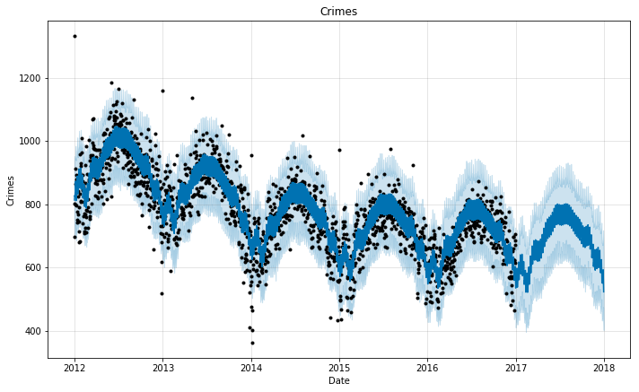

```python
from fbprophet import Prophet
crime_model = Prophet(interval_width=0.95)
crime_data = df_date_group.rename(columns={'dates': 'ds', 'Freq': 'y'})
crime_model.fit(crime_data)

crime_forecast = crime_model.make_future_dataframe(periods=365, freq='D')
crime_forecast = crime_model.predict(crime_forecast)
plt.figure(figsize=(20, 6))
crime_model.plot(crime_forecast, xlabel = 'Date', ylabel = 'Crimes')
plt.title('Crimes');
```

### Plotting the trend

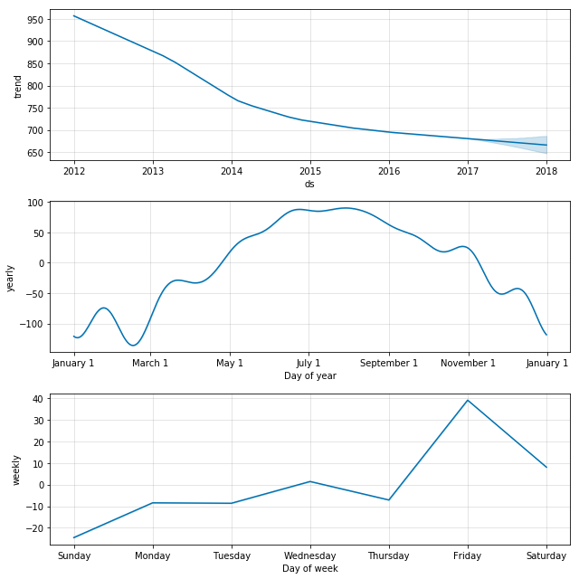

```python
crime_model.plot_components(crime_forecast);
```

### Actual vs Predicted Crimes 2017-2018

#### Actual crimes in 2017 - 267817

```python
crime_forecast[crime_forecast['ds']>='2017-01-01']['yhat'].sum()
```

```
262607.9291577991
```

#### Predicted Crimes in 2017 - 262608

### Plotting the above graph in Bokeh to make it interactive

```python
from bokeh.plotting import figure, show, output_notebook
from bokeh.models import HoverTool,ColumnDataSource,RangeTool,LegendItem,Legend
from bokeh.layouts import column
from bokeh.io import output_file,save
from bokeh.layouts import row,gridplot
from numpy import histogram, linspace
from scipy.stats.kde import gaussian_kde

output_notebook()

source_prophet = ColumnDataSource(data=dict(date=crime_forecast.ds,y=crime_forecast.yhat))
source_original = ColumnDataSource(data=dict(date=df_date_group.dates.dt.date,y=df_date_group.Freq))

prophet_forecast = figure(title='Total Crimes over the years (Predicted value in Red)',width=950, height=450,
            tools='save,wheel_zoom,pan,reset,box_zoom',x_axis_type='datetime',sizing_mode="scale_width",x_range=(crime_forecast.ds.min(), crime_forecast.ds.max()))


prophet_forecast.scatter('date','y',source=source_original,line_width=2,
                         color='black',fill_alpha=0.5,size=2,legend='Actual Crimes')

prophet_forecast.line(crime_forecast.iloc[0:1827].ds,crime_forecast.iloc[0:1827].yhat,
                      line_width=2,color='blue',legend='Actual Value Trend')
prophet_forecast.line(crime_forecast.iloc[-365:].ds,crime_forecast.iloc[-365:].yhat,
                      line_width=2,color='red',line_alpha=0.3,legend='Predicted Value')
prophet_forecast.line(crime_forecast.ds,crime_forecast.yhat_lower,
                      line_width=2,color='lightblue',line_alpha=0.3,legend='95% Confidence Interval')
prophet_forecast.line(crime_forecast.ds,crime_forecast.yhat_upper,
                      line_width=2,color='lightblue',line_alpha=0.3)

prophet_forecast.xaxis.axis_label = "Year"
prophet_forecast.yaxis.axis_label = "Total Crimes"
prophet_forecast.xgrid.grid_line_color = None
prophet_forecast.ygrid.grid_line_color = None

prophet_train = figure(title="Date Selection",
                plot_height=100, plot_width=950, y_range=prophet_forecast.y_range,
                x_axis_type="datetime", y_axis_type=None,
                tools="", toolbar_location=None, background_fill_color="#efefef")


range_tool_prophet = RangeTool(x_range=prophet_forecast.x_range)
range_tool_prophet.overlay.fill_color = "navy"
range_tool_prophet.overlay.fill_alpha = 0.2

prophet_train.scatter('date', 'y', source=source_original,size=1)
prophet_train.line('date', 'y', source=source_prophet)


prophet_train.ygrid.grid_line_color = None
prophet_train.add_tools(range_tool_prophet)
prophet_train.toolbar.active_multi = range_tool_prophet

show(column(prophet_forecast,prophet_train))
# output_file("FBProphet_Output.html", title="FBProphet Output")
# save((prophet_forecast,prophet_train))
```

[interactive chart not shown]

### Predicting the crimes from Jan-01-2017- Dec-02-2018

```
INFO:fbprophet.forecaster:Disabling daily seasonality. Run prophet with daily_seasonality=True to override this.
```

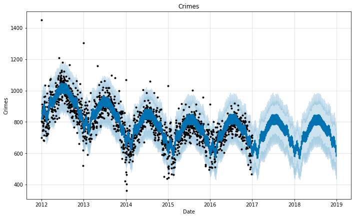

```python
from fbprophet import Prophet
crime_model = Prophet(interval_width=0.95)
crime_data = df_date_group.rename(columns={'dates': 'ds', 'Freq': 'y'})
crime_model.fit(crime_data)

crime_forecast = crime_model.make_future_dataframe(periods=730, freq='D')
crime_forecast = crime_model.predict(crime_forecast)
plt.figure(figsize=(20, 6))
crime_model.plot(crime_forecast, xlabel = 'Date', ylabel = 'Crimes')
plt.title('Crimes');
```

```python
crime_forecast[(crime_forecast['ds']>='2017-01-01')&(crime_forecast['ds']<='2018-12-02')]['yhat'].sum()
```

```
505532.35361045913
```

#### Actual crimes in 2018 till 2-Dec - 239221

#### Acutal crimes between Jan-1 2017 till Dec-2-2018 - 507038

#### Predicted crimes between Jan-1 2017 till Dec-2-2018 - 505532